# Generalized Linear models

Dmitry Kondrashov & Stefano Allesina

Fundamentals of Biological Data Analysis – BIOS 26318

# Goal

Learn about Generalized Linear Models (GLMs), and be able to decide which model is most appropriate for the problem at hand.

Let’s load some packages:

```r
library(VGAM)
library(MASS) # negative binom regression
library(tidyverse) # our friend the tidyverse
library(pscl) # zero-inflated and zero-hurdle models
source("general_code/read_xls_from_url.R") # function to read excel from URL
```

# Beyond linear regression

The basic framework of linear regression has been extended in several directions. For example,

- **Polynomial regression** which we have discussed briefly.
- [**Nonlinear regression**](https://en.wikipedia.org/wiki/Nonlinear_regression) where the parameters cannot be mapped into a linear transformation.
- [**Models with fixed and random effects**](http://support.sas.com/documentation/cdl/en/statug/63033/HTML/default/viewer.htm#statug_intromod_a0000000337.htm) where measurements are made over several “related groups”, you can introduce effects associated with each group. These models are part of the more general [**hierarchical models**](https://en.wikipedia.org/wiki/Multilevel_model).
- [**Models with latent variables**](http://www.econ.upf.edu/~michael/latentvariables/lecture1.pdf) where unmeasured variables need to be included to explain the data.
- [**Measurement error models**](https://en.wikipedia.org/wiki/Errors-in-variables_models) are used when the independent variables are measured with errors (i.e., are not known precisely).
- And many others!

# Generalized linear models (GLMs)

The linear regression we’ve explored during the past weeks attempts to estimate the expected value for **response** (dependent) variable $Y$ given the **predictors** $X$. It assumes that the response variable changes continuously, and that errors are normally distributed around the mean. In many cases, however, the response variable does not have support in the whole real line, or errors are not normally distributed. In these cases, one can use **Generalized Linear Models** to fit the data.

## Model structure

In practice, we need to determine three parts of the model:

- **Random component** the entries of the response variable ($Y$) are assumed to be independently drawn from a certain distribution (e.g., Binomial).
- **Systematic component** the explanatory variables ($X_1$, $X_2$, $\ldots$) are combined in a linear combination to form a **linear predictor** (e.g., $\beta_0 + \beta_1 X_1 + \beta_2 X_2 + \ldots$). The explanatory variables can be continuous, categorical, or mixed.
- **Link function** $g(u)$ specifies how the random and systematic components are connected.

# Binary data

The most extreme case of departure from normality is when the response variable can assume only values 0 or 1 (no/yes, survived/deceased, lost/won, etc.). A Bernoulli random variable can take values 0 or 1, and therefore provides the **Random component** of the model:

$$P(Y_i = y_i | \pi_i) = \pi_i^{y_i} (1 - \pi_i)^{1 - y_i}$$

Saying that the probability $P(Y_i = 1) = \pi_i$, and $P(Y_i = 0) = 1 - \pi_i$. Now we want to relate the parameter $\pi_i$ to the **linear predictor** (i.e., choose a link function). This can be accomplished in a number of ways.

## Logistic regression

The most popular choice is to use the *Logit* function as the link function:

$$\text{Logit}(\pi_i) = \beta_0 + \beta_1 x_i$$

where the function can be written as:

$$\text{Logit}(\pi_i) = \log\left( \frac{\pi_i}{1 - \pi_i} \right) = \log(\pi_i) - \log(1 - \pi_i)$$

Practically, this means that

$$\pi_i = \frac{e^{\beta_0 + \beta_1 x_i}}{1 + e^{\beta_0 + \beta_1 x_i}}$$

For example:

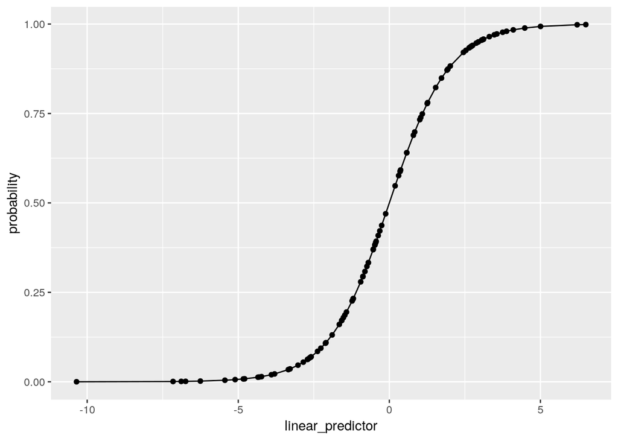

```r
# some random data
X <- rnorm(100)
beta_0 <- 0.35
beta_1 <- -3.2
linear_predictor <- beta_0 + beta_1 * X
predicted_pi_i <- exp(linear_predictor) / (1 + exp(linear_predictor))
ggplot(data = tibble(linear_predictor = linear_predictor, probability = predicted_pi_i)) +
  aes(x = linear_predictor, y = probability) +
  geom_point() + geom_line()
```

As you can see, this is a logistic curve, hence the name. The parameters $\beta_0$ and $\beta_1$ control the location of the inflection point and the steepness of the curve. To test this type of analysis, we are going to examine the data from:

> Long DS, Hou W, Taylor RS, McCowan LME (2016) [Serum levels of endothelial glycocalyx constituents in women at 20 weeks’ gestation who later develop gestational diabetes mellitus compared to matched controls: a pilot study](https://doi.org/10.1136/bmjopen-2016-011244). BMJ Open 6: e011244.

The Authors show that serum concentration of certain chemicals could predict the onset of Gestational Diabetes Mellitus (GDM). Load the data:

```r
long <- read_csv("data/Long_2016.csv")
head(long)
```

```
# # A tibble: 6 x 8
#     GDM Ethnicity Maternal_Age   BMI     H     C    Ha     S
#   <int>     <int>        <int> <dbl> <dbl> <dbl> <dbl> <dbl>
# 1     1         2           34  24.5  918.  999  18.5   431.
# 2     1         5           27  23.8  720.  999   7.95  612.
# 3     0         2           40  24.5  689.  999  15.4   158.
# 4     0         2           32  23   1228. 1798. 20.3   235.
# 5     0         5           26  23.6  804.  999  12.7   140.
# 6     1         2           28  23.7  840.  999  48.2   442.
```

```r
logistic <- glm(data = long, formula = GDM ~ BMI + Ha + Maternal_Age, family = "binomial")
summary(logistic)
```

```
#
# Call:
# glm(formula = GDM ~ BMI + Ha + Maternal_Age, family = "binomial",
#     data = long)
#
# Deviance Residuals:
#     Min       1Q   Median       3Q      Max
# -1.3392  -1.1226  -0.4036   1.1799   1.5120
#
# Coefficients:
#              Estimate Std. Error z value Pr(>|z|)
# (Intercept)  -2.00087    2.99325  -0.668    0.504
# BMI           0.02365    0.08486   0.279    0.780
# Ha            0.04812    0.03170   1.518    0.129
# Maternal_Age  0.01568    0.07083   0.221    0.825
#
# (Dispersion parameter for binomial family taken to be 1)
#
#     Null deviance: 55.452  on 39  degrees of freedom
# Residual deviance: 51.050  on 36  degrees of freedom
# AIC: 59.05
#
# Number of Fisher Scoring iterations: 5
```

In this case the model cannot explain much: let’s compute what is the differential probability for those with and without GDM.

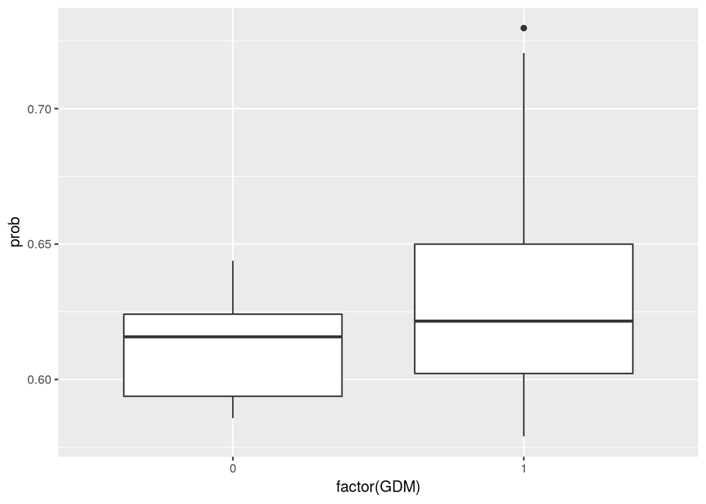

```r
long$predictor <- logistic$fitted.values
long <- long %>% mutate(prob = exp(predictor) / (1 + exp(predictor)))
long %>% ggplot() + aes(x = factor(GDM), y = prob) + geom_boxplot()
```

You can see that we cannot clealry separate the two cases.

## Probit regression

A similar model often used in econometric is the **probit**, which uses the c.d.f. of a normal distribution as the **link function**. In practice, the difference with the logistic regression is small.

```r
probit <- glm(data = long, formula = GDM ~ BMI + Ha + Maternal_Age, family = binomial(link = "probit"))
summary(probit)
```

```
#
# Call:
# glm(formula = GDM ~ BMI + Ha + Maternal_Age, family = binomial(link = "probit"),
#     data = long)
#
# Deviance Residuals:
#     Min       1Q   Median       3Q      Max
# -1.3371  -1.1261  -0.4393   1.1780   1.5035
#
# Coefficients:
#               Estimate Std. Error z value Pr(>|z|)
# (Intercept)  -1.196950   1.851578  -0.646    0.518
# BMI           0.013879   0.052115   0.266    0.790
# Ha            0.030010   0.018756   1.600    0.110
# Maternal_Age  0.008992   0.043872   0.205    0.838
#
# (Dispersion parameter for binomial family taken to be 1)
#
#     Null deviance: 55.452  on 39  degrees of freedom
# Residual deviance: 50.971  on 36  degrees of freedom
# AIC: 58.971
#
# Number of Fisher Scoring iterations: 6
```

As you can see from AIC, the quality of the fit is about the same as for the logit model.

# Count data

## Poisson regression

Suppose your response variables are nonnegative integers. For example, we are counting the number of eggs females lay as a function of their age, body size, etc. A possible model for this case is to think of the response variable as being sampled from a Poisson distribution:

$$Y_i \sim \text{Pois}(\lambda_i)$$

and that the logarithm of the parameter $\lambda_i$ depends linearly on the predictors:

$$\mathbb E[\lambda_i] = \mathbb E[\log(Y_i|X_i)] = \beta_0 + \beta_1 X_i$$

In this case, our *link function* is the logarithm, transforming the relationship between the fitted values and the predictors into a linear regression.

For a simple example, we look at the effect of wearing seatbelts on the number of drivers killed in accidents. Load the data:

```r
data("Seatbelts")
seat <- as.data.frame(Seatbelts)
```

and plot the histograms for before and after the law:

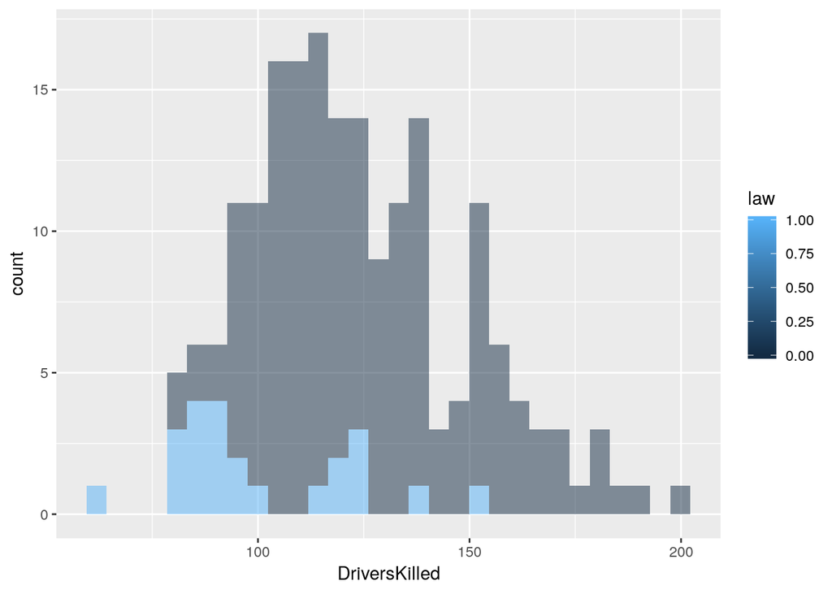

```r
library(tidyverse)
ggplot(data = seat) + aes(DriversKilled, fill = law, group = law) + geom_histogram(alpha = 0.5)
```

Now let’s perform a Poisson Regression using the predictor `law` to determine two different distributions:

```r
pois_reg <- glm(formula = DriversKilled ~ law, data = seat, family = "poisson")
summary(pois_reg)
```

```
#
# Call:
# glm(formula = DriversKilled ~ law, family = "poisson", data = seat)
#
# Deviance Residuals:
#     Min       1Q   Median       3Q      Max
# -4.4881  -1.6329  -0.5273   1.2394   5.9275
#
# Coefficients:
#              Estimate Std. Error z value Pr(>|z|)
# (Intercept)  4.835248   0.006856  705.22   <2e-16 ***
# law         -0.227473   0.021924  -10.38   <2e-16 ***
# ---
# Signif. codes:  0 '***' 0.001 '**' 0.01 '*' 0.05 '.' 0.1 ' ' 1
#
# (Dispersion parameter for poisson family taken to be 1)
#
#     Null deviance: 984.50  on 191  degrees of freedom
# Residual deviance: 870.06  on 190  degrees of freedom
# AIC: 2146.8
#
# Number of Fisher Scoring iterations: 4
```

Suggesting that the law significantly decreased deaths.

## Underdispersed and Overdispersed data

The main feature of the Poisson distribution is that the mean and the variance are both equal to $\lambda$. You might remember (Taylor expansion) that:

$$e^x = \sum_{n = 0}^{\infty} \frac{x^n}{n!}$$

Then, for $X$ sampled from a Poisson distribution:

$$\begin{aligned}
\mathbb E[X] &= \sum_{x = 0}^{\infty} x P(X = x) \\
&= \sum_{x = 0}^{\infty} x e^{-\lambda} \frac{\lambda^x}{x!} \\
&= \lambda e^{-\lambda} \sum_{(x - 1) = 0}^{\infty} \frac{\lambda^{(x-1)}}{(x-1)!} \\
&= \lambda e^{-\lambda}e^{\lambda} \\
&= \lambda
\end{aligned}$$

Similarly,
$$\begin{aligned}
\mathbb V[X] &= \mathbb E[X^2]-\mathbb E[X]^2\\
&= \left(\sum_{x = 0}^{\infty} x^2 e^{-\lambda} \frac{\lambda^x}{x!} \right) - \lambda^2 \\
&= \left(\lambda e^{-\lambda} \sum_{(x - 1) = 0}^{\infty} x \frac{\lambda^{(x-1)}}{(x-1)!}\right) - \lambda^2 \\
&= \left(\lambda e^{-\lambda} \left(\sum_{(x - 1) = 0}^{\infty} (x-1) \frac{\lambda^{(x-1)}}{(x-1)!} + \sum_{(x - 1) = 0}^{\infty} \frac{\lambda^{(x-1)}}{(x-1)!} \right) \right) - \lambda^2 \\
&= \left(
\lambda e^{-\lambda}
\left(
\lambda \sum_{(x - 2) = 0}^{\infty} (x-2) \frac{\lambda^{(x-2)}}{(x-2)!} + e^\lambda \right)\right) - \lambda^2 \\
&= \left(\lambda e^{-\lambda} (\lambda e^\lambda + e^\lambda) \right) - \lambda^2\\
&= \lambda
\end{aligned}$$

But do the data comply with this property? Let’s find out:

```r
seat %>% group_by(law) %>% summarise(avg_deaths = mean(DriversKilled), sd_deaths = var(DriversKilled))
```

```
# # A tibble: 2 x 3
#     law avg_deaths sd_deaths
#   <dbl>      <dbl>     <dbl>
# 1     0       126.      589.
# 2     1       100.      494.
```

Not really. We have **overdispersed** data (i.e., the variance is much larger than what assumed by Poisson). This happens very often, and the main tool to use is a **Negative Binomial Regression** (a negative binomial distribution can be thought of as a Poisson with a scaled variance):

```r
# the function is contained in the MASS package
nb_reg <- MASS::glm.nb(formula = DriversKilled ~ law, data = seat)
summary(nb_reg)
```

```
#
# Call:
# MASS::glm.nb(formula = DriversKilled ~ law, data = seat, init.theta = 35.14865118,
#     link = log)
#
# Deviance Residuals:
#     Min       1Q   Median       3Q      Max
# -2.3531  -0.7781  -0.2479   0.5839   2.6062
#
# Coefficients:
#             Estimate Std. Error z value Pr(>|z|)
# (Intercept)  4.83525    0.01468 329.488  < 2e-16 ***
# law         -0.22747    0.04343  -5.238 1.62e-07 ***
# ---
# Signif. codes:  0 '***' 0.001 '**' 0.01 '*' 0.05 '.' 0.1 ' ' 1
#
# (Dispersion parameter for Negative Binomial(35.1487) family taken to be 1)
#
#     Null deviance: 218.60  on 191  degrees of freedom
# Residual deviance: 191.95  on 190  degrees of freedom
# AIC: 1757.5
#
# Number of Fisher Scoring iterations: 1
#
#
#               Theta:  35.15
#           Std. Err.:  4.59
#
#  2 x log-likelihood:  -1751.521
```

Another option is a “quasipoisson” family, in which an extra parameter is fit to account for over-/under-dispersion:

```r
qpois_reg <- glm(formula = DriversKilled ~ law, data = seat, family = "quasipoisson")
summary(qpois_reg)
```

```
#
# Call:
# glm(formula = DriversKilled ~ law, family = "quasipoisson", data = seat)
#
# Deviance Residuals:
#     Min       1Q   Median       3Q      Max
# -4.4881  -1.6329  -0.5273   1.2394   5.9275
#
# Coefficients:
#             Estimate Std. Error t value Pr(>|t|)
# (Intercept)  4.83525    0.01487 325.107  < 2e-16 ***
# law         -0.22747    0.04756  -4.783 3.45e-06 ***
# ---
# Signif. codes:  0 '***' 0.001 '**' 0.01 '*' 0.05 '.' 0.1 ' ' 1
#
# (Dispersion parameter for quasipoisson family taken to be 4.705368)
#
#     Null deviance: 984.50  on 191  degrees of freedom
# Residual deviance: 870.06  on 190  degrees of freedom
# AIC: NA
#
# Number of Fisher Scoring iterations: 4
```

Given that for a Poisson the overdispersion parameter would be 1, and we obtain 4.7 when we allow our model to tune dispersion, we have a strong overdispersion. Always check this when relying on Poisson regression!

## Separate distribution for the zeros

In several cases, we have an excess of zeros. For example, you might have animals, that, if they reach the age of 1, will go on to a live a number of years—say well-described by a Poisson distribution. However, mortality immediately after birth is high. In such cases, you can use zero-inflated or zero-hurdle models.

In zero-inflated models, you can think of having a conditional branching: with probability $p_z$ your count is zero; if not (prob. $1-p_z$) it is sampled from a given distribution. As such a count of zero can stem from two different processes: either because you got a zero at the first step, or because you have sampled a zero from the distribution.

Zero-hurdle models are slightly different: you first decide whether you’re going to have a zero; if not, you sample your data from a truncated distribution, such that you cannot sample a zero from this second source.

To test this type of models, we’re going to use data from:

> Costanzo A, Ambrosini R, Caprioli M, Gatti E, Parolini M, Canova L, Rubolini D, Romano A, Gianfranceschi L, Saino N (2017) [Lifetime reproductive success, selection on lifespan, and multiple sexual ornaments in male European barn swallows](https://doi.org/10.1111/evo.13312). Evolution 71(10): 2457-2468.

```r
# Original URL
# https://datadryad.org/bitstream/handle/10255/dryad.151697/evolution_data_17-0084.R2.xls
dt <- read_xls_from_url("https://tinyurl.com/y8kvkwjp")
# select only interesting cols
dt <- dt %>% select(ID_male, tot_offspring, tail_l)
# remove NAs
dt <- dt %>% filter(!is.na(tot_offspring), !is.na(tail_l))
```

Let’s take a look:

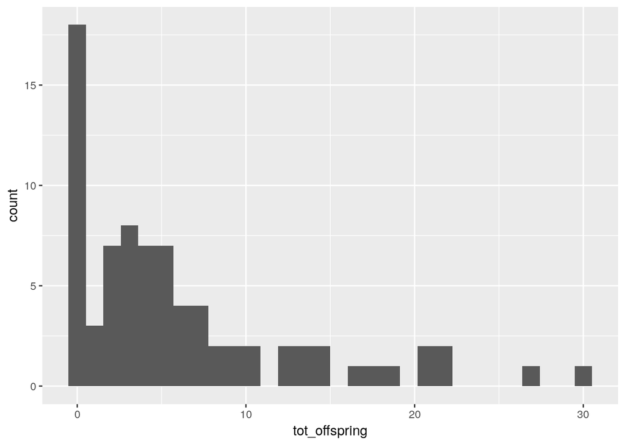

```r
dt %>% ggplot() + aes(x = tot_offspring) + geom_histogram()
```

You can clearly see the excess of zeros. Let’s start with a Poisson, and work our way up:

```r
# Poisson
model1 <- glm(data = dt, tot_offspring ~ tail_l, family = "poisson")
model1
```

```
#
# Call:  glm(formula = tot_offspring ~ tail_l, family = "poisson", data = dt)
#
# Coefficients:
# (Intercept)       tail_l
#    -3.13374      0.04616
#
# Degrees of Freedom: 78 Total (i.e. Null);  77 Residual
# Null Deviance:        560.8
# Residual Deviance: 474.2  AIC: 698.7
```

```r
# Negative Binomial
model2 <- MASS::glm.nb(data = dt, tot_offspring ~ tail_l)
model2
```

```
#
# Call:  MASS::glm.nb(formula = tot_offspring ~ tail_l, data = dt, init.theta = 0.9247088243,
#     link = log)
#
# Coefficients:
# (Intercept)       tail_l
#    -4.15104      0.05564
#
# Degrees of Freedom: 78 Total (i.e. Null);  77 Residual
# Null Deviance:        104.7
# Residual Deviance: 92.19  AIC: 450
```

```r
# Zero-inflated Poisson
model3 <- zeroinfl(data = dt, tot_offspring ~ tail_l, dist = "pois")
model3
```

```
#
# Call:
# zeroinfl(formula = tot_offspring ~ tail_l, data = dt, dist = "pois")
#
# Count model coefficients (poisson with log link):
# (Intercept)       tail_l
#    -1.27442      0.03101
#
# Zero-inflation model coefficients (binomial with logit link):
# (Intercept)       tail_l
#     11.3670      -0.1217
```

```r
AIC(model3)
```

```
# [1] 577.7295
```

```r
# Zero-inflated Negative Binomial
model4 <- zeroinfl(data = dt, tot_offspring ~ tail_l, dist = "negbin")
model4
```

```
#
# Call:
# zeroinfl(formula = tot_offspring ~ tail_l, data = dt, dist = "negbin")
#
# Count model coefficients (negbin with log link):
# (Intercept)       tail_l
#     -1.7577       0.0348
# Theta = 1.6185
#
# Zero-inflation model coefficients (binomial with logit link):
# (Intercept)       tail_l
#      16.416       -0.176
```

```r
AIC(model4)
```

```
# [1] 444.3008
```

```r
# Zero-hurdle Poisson
model5 <- hurdle(data = dt, tot_offspring ~ tail_l, dist = "pois")
model5
```

```
#
# Call:
# hurdle(formula = tot_offspring ~ tail_l, data = dt, dist = "pois")
#
# Count model coefficients (truncated poisson with log link):
# (Intercept)       tail_l
#      -1.273        0.031
#
# Zero hurdle model coefficients (binomial with logit link):
# (Intercept)       tail_l
#    -11.4389       0.1223
```

```r
AIC(model5)
```

```
# [1] 577.742
```

```r
# Zero-hurdle Negative Binomial
model6 <- hurdle(data = dt, tot_offspring ~ tail_l, dist = "negbin")
model6
```

```
#
# Call:
# hurdle(formula = tot_offspring ~ tail_l, data = dt, dist = "negbin")
#
# Count model coefficients (truncated negbin with log link):
# (Intercept)       tail_l
#    -1.85825      0.03584
# Theta = 1.7111
#
# Zero hurdle model coefficients (binomial with logit link):
# (Intercept)       tail_l
#    -11.4389       0.1223
```

```r
AIC(model6)
```

```
# [1] 444.8101
```

Zero-inflated and zero-hurdle models are examples of [**mixture models**](https://en.wikipedia.org/wiki/Mixture_model).

# Other GLMs

Historically, GLMs have been defined for the canonical families:

- Gaussian: linear regression
- Gamma and Inverse Gaussian: Positive, continuous
- Poisson: count data
- Negative Binomial: count data (fit an ancillary parameter for overdispersion)
- Binary/Binomial (logistic): binary responses; number of successes

However, the same basic idea led to the development of “non-canonical” GLMs:

- Lognormal: Positive, continuous
- Log-gamma: survival models
- Probit: binary

and many others. Fitting the models can be done using Maximum Likelihoods, or in a Bayesian framework (typically, through MCMC).

# Example

[Data](https://doi.org/10.5061/dryad.g4q84) from the paper:

> Kallio ER, Helle H, Koskela E, Mappes T, Vapalahti O (2015) [Age-related effects of chronic hantavirus infection on female host fecundity](https://doi.org/10.1111/1365-2656.12387). Journal of Animal Ecology 84(5): 1264–1272.

```r
# read the data
# use short URL
# original: datadryad.org/bitstream/handle/10255/dryad.84805/Litter_data.xlsx
dat <- read_xlsx_from_url("https://tinyurl.com/y88w7xe6")
# show the data
head(dat)
```

```
# # A tibble: 6 x 9
#      RE  mocond pupcond PUUV_INF c_mohea litter_size season cycle random
#   <dbl>   <dbl>   <dbl>    <dbl>   <dbl>       <dbl>  <dbl> <dbl>  <dbl>
# 1  0.7  -1.27    -1.40         1 -0.153            5      1     3      1
# 2  0.48 -0.214    1.59         1 -0.753            3      1     3      2
# 3  0.89 -1.11    -1.43         0  0.0471           6      1     3      3
# 4  0.62 -1.11     0.190        1  0.0471           4      1     3      4
# 5  0.7  -0.0454   0.181        1 -0.653            5      1     3      4
# 6  0.74 -0.421    0.274        1 -0.353            5      1     3      5
```

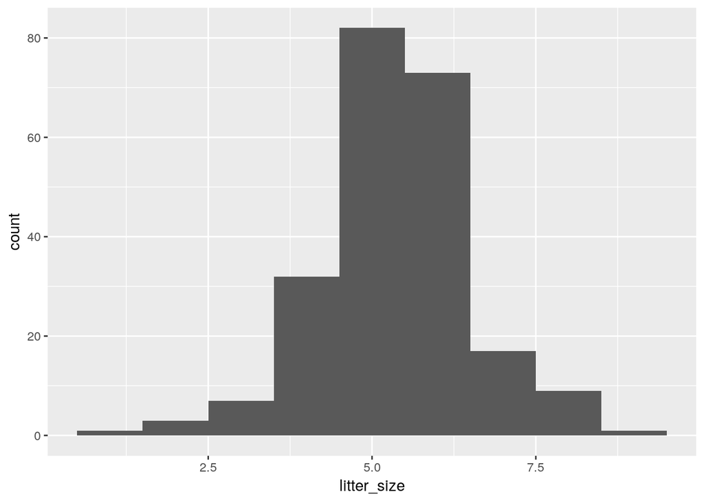

```r
# plot litter sizes
dat %>% ggplot(aes(x = litter_size)) + geom_histogram(binwidth = 1)
```

Let’s write the likelihood function for the Poisson distribution

```r
log_likelihood_Poisson <- function(my_data, my_lambda){
  return(sum(log(dpois(my_data, my_lambda))))
}
```

For example:

```r
log_likelihood_Poisson(dat$litter_size, 3)
```

```
# [1] -594.6209
```

```r
log_likelihood_Poisson(dat$litter_size, 5)
```

```
# [1] -429.5869
```

But what is the maximum likelihood estimate for $\lambda$?

```r
# use optim(initial guess, function to maximize, other named parameters)
# we use method Brent that looks for the maximum in an interval
# we set control = list(fnscale = -1)
# to maximize instead of minimize (default) the function
find_lambda <- optim(5, log_likelihood_Poisson,
                     my_data = dat$litter_size,
                     method = "Brent", lower = 0, upper = 10,
                     control = list(fnscale = -1))
find_lambda
```

```
# $par
# [1] 5.351111
#
# $value
# [1] -426.8759
#
# $counts
# function gradient
#       NA       NA
#
# $convergence
# [1] 0
#
# $message
# NULL
```

Let’s store the best parameter and maximum likelihood:

```r
lambda_hat <- find_lambda$par
max_likelihood_Poisson <- find_lambda$value
```

Using Poisson regression

```r
model1 <- glm(litter_size ~ 1., family = "poisson", data = dat)
exp(model1$coefficients[1])
```

```
# (Intercept)
#    5.351111
```

Compute AIC:

```r
AIC(model1)
```

```
# [1] 855.7517
```

Now let’s see whether the infection status can help us explain the litter size:

```r
model2 <- glm(litter_size ~ PUUV_INF, family = "poisson", data = dat)
summary(model2)
```

```
#
# Call:
# glm(formula = litter_size ~ PUUV_INF, family = "poisson", data = dat)
#
# Deviance Residuals:
#     Min       1Q   Median       3Q      Max
# -2.3117  -0.1548  -0.1525   0.2761   1.4366
#
# Coefficients:
#              Estimate Std. Error z value Pr(>|z|)
# (Intercept) 1.6768792  0.0380693  44.048   <2e-16 ***
# PUUV_INF    0.0009959  0.0582649   0.017    0.986
# ---
# Signif. codes:  0 '***' 0.001 '**' 0.01 '*' 0.05 '.' 0.1 ' ' 1
#
# (Dispersion parameter for poisson family taken to be 1)
#
#     Null deviance: 61.839  on 224  degrees of freedom
# Residual deviance: 61.839  on 223  degrees of freedom
# AIC: 857.75
#
# Number of Fisher Scoring iterations: 4
```

```r
AIC(model2)
```

```
# [1] 857.7514
```

Not really! In fact, the effect is to simply add a parameter. Now let’s look at over/underdispersion:

```r
summary(glm(litter_size ~ PUUV_INF, family = "quasipoisson", data = dat))
```

```
#
# Call:
# glm(formula = litter_size ~ PUUV_INF, family = "quasipoisson",
#     data = dat)
#
# Deviance Residuals:
#     Min       1Q   Median       3Q      Max
# -2.3117  -0.1548  -0.1525   0.2761   1.4366
#
# Coefficients:
#              Estimate Std. Error t value Pr(>|t|)
# (Intercept) 1.6768792  0.0195052  85.971   <2e-16 ***
# PUUV_INF    0.0009959  0.0298526   0.033    0.973
# ---
# Signif. codes:  0 '***' 0.001 '**' 0.01 '*' 0.05 '.' 0.1 ' ' 1
#
# (Dispersion parameter for quasipoisson family taken to be 0.2625132)
#
#     Null deviance: 61.839  on 224  degrees of freedom
# Residual deviance: 61.839  on 223  degrees of freedom
# AIC: NA
#
# Number of Fisher Scoring iterations: 4
```

The data is highly underdispersed! The variance is about 1/4 of what expected using a Poisson distribution. Hence, using a more flexible distribution should help considerably. When the data are overdispersed, we’ve used the negative binomial regression. When they’re underdispersed, a possible choice is the Generalized Poisson regression:

```r
model3 <- VGAM::vglm(litter_size ~ 1, family = "genpoisson", data = dat)
summary(model3)
```

```
#
# Call:
# VGAM::vglm(formula = litter_size ~ 1, family = "genpoisson",
#     data = dat)
#
#
# Pearson residuals:
#                    Min      1Q  Median     3Q    Max
# rhobit(lambda) -0.7192 -0.7192 -0.4253 0.1127 11.093
# loge(theta)    -2.2560 -0.4118 -0.4118 0.3607  6.054
#
# Coefficients:
#               Estimate Std. Error z value Pr(>|z|)
# (Intercept):1 -2.97974    0.92937      NA       NA
# (Intercept):2  2.32089    0.05156   45.01   <2e-16 ***
# ---
# Signif. codes:  0 '***' 0.001 '**' 0.01 '*' 0.05 '.' 0.1 ' ' 1
#
# Number of linear predictors:  2
#
# Names of linear predictors: rhobit(lambda), loge(theta)
#
# Log-likelihood: -358.0462 on 448 degrees of freedom
#
# Number of iterations: 8
#
# Warning: Hauck-Donner effect detected in the following estimate(s):
# '(Intercept):1'
```

```r
AIC(model3)
```

```
# [1] 720.0925
```

# Readings

- [Regression Models for Count Data in R](https://cran.r-project.org/web/packages/pscl/vignettes/countreg.pdf)